# Kaggle Titantic Workflow

The workflow is to introduce the usage of the package *kaggletitanic*. We will go through the process of

1. Data munging and cleaning
2. Building model
3. Model evaluation
4. Data prediction

# Data munging and cleaning

Load the library and then train and test data.

```r
library("kaggletitanic")
train.df = get.train.data()
test.df = get.test.data()
```

In functions `get.train.data` and `get.train.data`, the data is cleaned, e.g. all the gaps are filled and new variables are added.

Split the training data into two sets. Current the default splitting is 80% to the batched and another 20% to the unbatched.

```r
splitted.rows.index = split.data.rows(train.df);
train.df.batch = train.df[splitted.rows.index,];
train.df.unbatch = train.df[-splitted.rows.index,];
```

# Building model

After cleaning the data, we can then work to build the model. There is a default formula we can always employ by `get.default.formula`

```r
get.default.formula()
```

```
## Survived ~ Sex + Pclass + Title2 + FamilySize + IsNoble + Embarked +
##     Age + IsNaCabin + IsPoorOld + IsRichGirl + Fare2
## <environment: 0x000000001ad76bc0>
```

The package contains a few learning method:

### Generalized linear model

```r
glm.tune = glm.train(get.default.formula(), train.df.batch);
glm.tune
```

```
## Generalized Linear Model
##
## 714 samples
##  23 predictor
##   2 classes: 'Perish', 'Survive'
##
## No pre-processing
## Resampling: Cross-Validated (10 fold, repeated 10 times)
##
## Summary of sample sizes: 643, 643, 643, 642, 643, 643, ...
##
## Resampling results
##
##   ROC        Sens       Spec       ROC SD      Sens SD     Spec SD
##   0.8857565  0.9068182  0.7267593  0.04062385  0.04267195  0.07139646
##
##
```

### Gradient boosting model

```r
gbm.tune = gbm.train(get.default.formula(), train.df.batch, get.gbm.grid());
```

### Other models

```r
## Stochastic boosting
ada.tune = ada.train(get.default.formula(), train.df.batch);
## Support vector machines
svm.tune = svm.train(get.default.formula(), train.df.batch);
## Neural network model
net.tune = net.train(get.default.formula(), train.df.batch);
```

# Model Evalution

- Confusion matrix and statistics After running models, we can then use them to predict the unbatched training data. Compare the results from the unbatched training data, we can have a brief understanding which model performs better.

```r
train.accuracy(gbm.tune, train.df.unbatch)
```

```
## Confusion Matrix and Statistics
##
##           Reference
## Prediction Perish Survive
##    Perish      90      16
##    Survive     19      52
##
##                Accuracy : 0.8023
##                  95% CI : (0.7359, 0.8582)
##     No Information Rate : 0.6158
##     P-Value [Acc > NIR] : 7.432e-08
##
##                   Kappa : 0.5855
##  Mcnemar's Test P-Value : 0.7353
##
##             Sensitivity : 0.8257
##             Specificity : 0.7647
##          Pos Pred Value : 0.8491
##          Neg Pred Value : 0.7324
##              Prevalence : 0.6158
##          Detection Rate : 0.5085
##    Detection Prevalence : 0.5989
##       Balanced Accuracy : 0.7952
##
##        'Positive' Class : Perish
##
```

```r
train.accuracy(svm.tune, train.df.unbatch)
```

```
## Confusion Matrix and Statistics
##
##           Reference
## Prediction Perish Survive
##    Perish      94      19
##    Survive     15      49
##
##                Accuracy : 0.8079
##                  95% CI : (0.7421, 0.8632)
##     No Information Rate : 0.6158
##     P-Value [Acc > NIR] : 2.854e-08
##
##                   Kappa : 0.5895
##  Mcnemar's Test P-Value : 0.6069
##
##             Sensitivity : 0.8624
##             Specificity : 0.7206
##          Pos Pred Value : 0.8319
##          Neg Pred Value : 0.7656
##              Prevalence : 0.6158
##          Detection Rate : 0.5311
##    Detection Prevalence : 0.6384
##       Balanced Accuracy : 0.7915
##
##        'Positive' Class : Perish
##
```

1. Accuracy: Measures the total percentage the model predicts correctly.
2. 95% CI: 95% confidence interval. The narrow the range the more stable the model.
3. Sensitivity: Measures the correct prediction rate of Perish.
4. Specificity: Measures the correct prediction rate of Survive.
- ROC

We can also plot the roc curves on the models.

```r
glm.roc = get.roc(glm.tune, train.df.unbatch)
gbm.roc = get.roc(gbm.tune, train.df.unbatch)
rf.roc = get.roc(rf.tune, train.df.unbatch)
ada.roc = get.roc(ada.tune, train.df.unbatch)
svm.roc = get.roc(svm.tune, train.df.unbatch)
net.roc = get.roc(net.tune, train.df.unbatch)
```

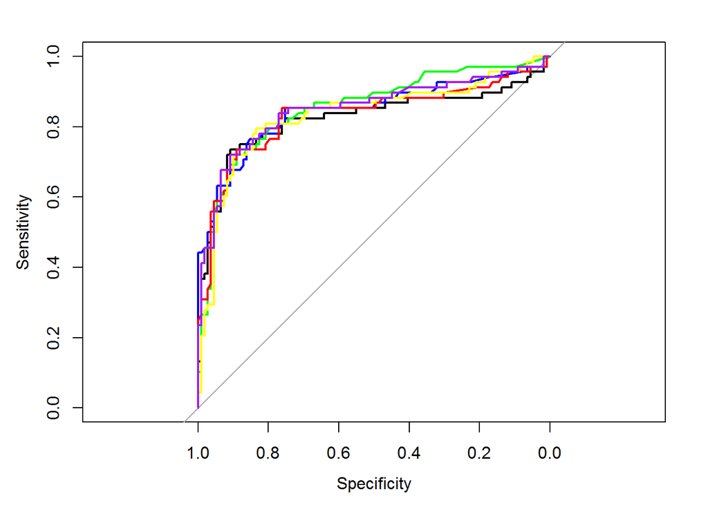

```r
library("pROC")
plot(glm.roc, type="S")
plot(gbm.roc, add=TRUE, col="blue")
plot(rf.roc, add=TRUE, col="green")
plot(ada.roc, add=TRUE, col="red")
plot(svm.roc, add=TRUE, col="yellow")
plot(net.roc, add=TRUE, col="purple")
```

# Data Prediction

After selecting the best model, assuming `gbm` performs the best, we can then predict the test data on it.

```r
test.pred = test.predict(gbm.tune, test.df)
```

The prediction is finally generated under the directory `data`.